# Project: Investigate a Dataset - TMDb Movie Data Analysis

- Introduction
- Data Wrangling
- Exploratory Data Analysis
- Conclusions

## Introduction

### Questions for Analysis

> What levels of average vote ratings yield the highest average adjusted revenue?

> Do movies with high popularity yield higher adjusted revenue?

> Do higher runtime movies yield higher adjusted revenues?

```python
# To analyze the data, we will be using pandas, numpy, and matplotlib libraries
import pandas as pd
import numpy as np
import matplotlib.pyplot as plt
%matplotlib inline
```

```python
# Upgrade pandas to use dataframe.explode() function.
!pip install --upgrade pandas==0.25.0
```

## Data Wrangling

> In this section of the report, we will load in the data and the required libraries, check for cleanliness, and then trim and clean the dataset for analysis.

```python
# Load your data and print out a few lines. Perform operations to inspect data
#   types and look for instances of missing or possibly errant data.
df = pd.read_csv('tmdb-movies.csv')
df.head(2)
```

|  | id | imdb_id | popularity | budget | revenue | original_title | cast | homepage | director | tagline | ... | overview | runtime | genres | production_companies | release_date | vote_count | vote_average | release_year | budget_adj | revenue_adj |
| --- | --- | --- | --- | --- | --- | --- | --- | --- | --- | --- | --- | --- | --- | --- | --- | --- | --- | --- | --- | --- | --- |
| 0 | 135397 | tt0369610 | 32.985763 | 150000000 | 1513528810 | Jurassic World | Chris Pratt\|Bryce Dallas Howard\|Irrfan Khan\|Vi... | http://www.jurassicworld.com/ | Colin Trevorrow | The park is open. | ... | Twenty-two years after the events of Jurassic ... | 124 | Action\|Adventure\|Science Fiction\|Thriller | Universal Studios\|Amblin Entertainment\|Legenda... | 6/9/15 | 5562 | 6.5 | 2015 | 1.379999e+08 | 1.392446e+09 |
| 1 | 76341 | tt1392190 | 28.419936 | 150000000 | 378436354 | Mad Max: Fury Road | Tom Hardy\|Charlize Theron\|Hugh Keays-Byrne\|Nic... | http://www.madmaxmovie.com/ | George Miller | What a Lovely Day. | ... | An apocalyptic story set in the furthest reach... | 120 | Action\|Adventure\|Science Fiction\|Thriller | Village Roadshow Pictures\|Kennedy Miller Produ... | 5/13/15 | 6185 | 7.1 | 2015 | 1.379999e+08 | 3.481613e+08 |

2 rows × 21 columns

```python
#suppress scientific form in variables
pd.set_option('display.float_format', lambda x: '%.5f' % x)
```

```python
# view the variables index and variable names in the dataset
for i, v in enumerate (df.columns):
    print(i,v)
```

```
0 id
1 imdb_id
2 popularity
3 budget
4 revenue
5 original_title
6 cast
7 homepage
8 director
9 tagline
10 keywords
11 overview
12 runtime
13 genres
14 production_companies
15 release_date
16 vote_count
17 vote_average
18 release_year
19 budget_adj
20 revenue_adj
```

```python
#check for columns with missing values and the corresponding data types
df.info()
```

```
<class 'pandas.core.frame.DataFrame'>
RangeIndex: 10866 entries, 0 to 10865
Data columns (total 21 columns):
id                      10866 non-null int64
imdb_id                 10856 non-null object
popularity              10866 non-null float64
budget                  10866 non-null int64
revenue                 10866 non-null int64
original_title          10866 non-null object
cast                    10790 non-null object
homepage                2936 non-null object
director                10822 non-null object
tagline                 8042 non-null object
keywords                9373 non-null object
overview                10862 non-null object
runtime                 10866 non-null int64
genres                  10843 non-null object
production_companies    9836 non-null object
release_date            10866 non-null object
vote_count              10866 non-null int64
vote_average            10866 non-null float64
release_year            10866 non-null int64
budget_adj              10866 non-null float64
revenue_adj             10866 non-null float64
dtypes: float64(4), int64(6), object(11)
memory usage: 1.7+ MB
```

> Inspecting the data using the info() reveales that the data contained 10866 observations and 21 features. However, the features, cast, tagline, homepage, director, keywords, overview, genres, and production companies contained missing values. Since, there are a few missing values in cast, director, overview and genres columns, we will drop the missing values. Additionally, since homepage, tagline and keywords had many missing values and were irrelevant to our research questions, we will drop these columns.  
> On examining the data types, there were problems with data types. Thus, we will need to convert the data types appropriately.

```python
#Obtain summary statistics to check for outliers and missingness in the data
df.describe()
```

|  | id | popularity | budget | revenue | runtime | vote_count | vote_average | release_year | budget_adj | revenue_adj |
| --- | --- | --- | --- | --- | --- | --- | --- | --- | --- | --- |
| count | 10866.00000 | 10866.00000 | 10866.00000 | 10866.00000 | 10866.00000 | 10866.00000 | 10866.00000 | 10866.00000 | 10866.00000 | 10866.00000 |
| mean | 66064.17743 | 0.64644 | 14625701.09415 | 39823319.79339 | 102.07086 | 217.38975 | 5.97492 | 2001.32266 | 17551039.82289 | 51364363.25325 |
| std | 92130.13656 | 1.00018 | 30913213.83144 | 117003486.58208 | 31.38141 | 575.61906 | 0.93514 | 12.81294 | 34306155.72284 | 144632485.03998 |
| min | 5.00000 | 0.00007 | 0.00000 | 0.00000 | 0.00000 | 10.00000 | 1.50000 | 1960.00000 | 0.00000 | 0.00000 |
| 25% | 10596.25000 | 0.20758 | 0.00000 | 0.00000 | 90.00000 | 17.00000 | 5.40000 | 1995.00000 | 0.00000 | 0.00000 |
| 50% | 20669.00000 | 0.38386 | 0.00000 | 0.00000 | 99.00000 | 38.00000 | 6.00000 | 2006.00000 | 0.00000 | 0.00000 |
| 75% | 75610.00000 | 0.71382 | 15000000.00000 | 24000000.00000 | 111.00000 | 145.75000 | 6.60000 | 2011.00000 | 20853251.08440 | 33697095.71731 |
| max | 417859.00000 | 32.98576 | 425000000.00000 | 2781505847.00000 | 900.00000 | 9767.00000 | 9.20000 | 2015.00000 | 425000000.00000 | 2827123750.41189 |

> Based on the descriptive analysis, there were many zeros in the budget and revenue columns. It's very unrealistic to have a movie produced with zero budget and also yield zero revenue. Also, when I checked for missingness, it was clear that all the movies were released and hence, no missing value. This indicates that the zeros in the revenue and budget columns are actually missing. However, to confirm whether the zeros represents small amount or just missing, I went ahead and filtered the data by zero using the query pandas function.

```python
# filter the budget column using 0
df_budget_0 = df.query('budget == 0')
df_budget_0.head(1)
```

|  | id | imdb_id | popularity | budget | revenue | original_title | cast | homepage | director | tagline | ... | overview | runtime | genres | production_companies | release_date | vote_count | vote_average | release_year | budget_adj | revenue_adj |
| --- | --- | --- | --- | --- | --- | --- | --- | --- | --- | --- | --- | --- | --- | --- | --- | --- | --- | --- | --- | --- | --- |
| 30 | 280996 | tt3168230 | 3.92733 | 0 | 29355203 | Mr. Holmes | Ian McKellen\|Milo Parker\|Laura Linney\|Hattie M... | http://www.mrholmesfilm.com/ | Bill Condon | The man behind the myth | ... | The story is set in 1947, following a long-ret... | 103 | Mystery\|Drama | BBC Films\|See-Saw Films\|FilmNation Entertainme... | 6/19/15 | 425 | 6.40000 | 2015 | 0.00000 | 27006774.87702 |

1 rows × 21 columns

```python
df_budget_adj_0 = df.query('budget_adj == 0')
df_budget_adj_0 .head(1)
```

|  | id | imdb_id | popularity | budget | revenue | original_title | cast | homepage | director | tagline | ... | overview | runtime | genres | production_companies | release_date | vote_count | vote_average | release_year | budget_adj | revenue_adj |
| --- | --- | --- | --- | --- | --- | --- | --- | --- | --- | --- | --- | --- | --- | --- | --- | --- | --- | --- | --- | --- | --- |
| 30 | 280996 | tt3168230 | 3.92733 | 0 | 29355203 | Mr. Holmes | Ian McKellen\|Milo Parker\|Laura Linney\|Hattie M... | http://www.mrholmesfilm.com/ | Bill Condon | The man behind the myth | ... | The story is set in 1947, following a long-ret... | 103 | Mystery\|Drama | BBC Films\|See-Saw Films\|FilmNation Entertainme... | 6/19/15 | 425 | 6.40000 | 2015 | 0.00000 | 27006774.87702 |

1 rows × 21 columns

```python
df_revenue_0 = df.query('revenue == 0')
df_revenue_0.head(1)
```

|  | id | imdb_id | popularity | budget | revenue | original_title | cast | homepage | director | tagline | ... | overview | runtime | genres | production_companies | release_date | vote_count | vote_average | release_year | budget_adj | revenue_adj |
| --- | --- | --- | --- | --- | --- | --- | --- | --- | --- | --- | --- | --- | --- | --- | --- | --- | --- | --- | --- | --- | --- |
| 48 | 265208 | tt2231253 | 2.93234 | 30000000 | 0 | Wild Card | Jason Statham\|Michael Angarano\|Milo Ventimigli... | NaN | Simon West | Never bet against a man with a killer hand. | ... | When a Las Vegas bodyguard with lethal skills ... | 92 | Thriller\|Crime\|Drama | Current Entertainment\|Lionsgate\|Sierra / Affin... | 1/14/15 | 481 | 5.30000 | 2015 | 27599987.85601 | 0.00000 |

1 rows × 21 columns

```python
df_revenue_adj_0 = df.query('revenue_adj == 0')
df_revenue_adj_0 .head(1)
```

|  | id | imdb_id | popularity | budget | revenue | original_title | cast | homepage | director | tagline | ... | overview | runtime | genres | production_companies | release_date | vote_count | vote_average | release_year | budget_adj | revenue_adj |
| --- | --- | --- | --- | --- | --- | --- | --- | --- | --- | --- | --- | --- | --- | --- | --- | --- | --- | --- | --- | --- | --- |
| 48 | 265208 | tt2231253 | 2.93234 | 30000000 | 0 | Wild Card | Jason Statham\|Michael Angarano\|Milo Ventimigli... | NaN | Simon West | Never bet against a man with a killer hand. | ... | When a Las Vegas bodyguard with lethal skills ... | 92 | Thriller\|Crime\|Drama | Current Entertainment\|Lionsgate\|Sierra / Affin... | 1/14/15 | 481 | 5.30000 | 2015 | 27599987.85601 | 0.00000 |

1 rows × 21 columns

> After filtering the columns using zero, it is clear that the zeros are missing observations. Hence, they should either be replaced with NA or dropped from the dataset. To check whether they should be dropped or replaced with NA, I counted the number of missing values in each of the four columns. This is necessary because dropping many rows may make the data too small and hence, not representative.

```python
# counting zeros in budget column, and revenue column
budget_count= df.groupby('budget').count()['id']
revenue_count = df.groupby('revenue').count()['id']
print(budget_count.head(1),revenue_count.head(1))
```

```
budget
0    5696
Name: id, dtype: int64 revenue
0    6016
Name: id, dtype: int64
```

```python
budget_adj_count= df.groupby('budget_adj').count()['id']
revenue_adj_count = df.groupby('revenue_adj').count()['id']
print(budget_adj_count.head(1),revenue_adj_count.head(1))
```

```
budget_adj
0.00000    5696
Name: id, dtype: int64 revenue_adj
0.00000    6016
Name: id, dtype: int64
```

> After counting the zeros, it will be unrealistic to drop all the missing values as it will require dropping 5696 rows for the budget and budget_adj columns, 6016 for the revenue and revenue_adj column. Thus, the zeros will be replaced with Na for these columns.

```python
#check for duplicates
df.duplicated().sum()
```

```
1
```

> After checking for duplicate rows, one of the row appear to be duplicated. Hence, it will be dropped to obtain the clean data for analysis.

### Data Cleaning

> With the identified data problems in the data wrangling process, this section will employ appropriate data cleaning process, including imputing missing values, dropping irrelevant columns, changing variables data types appropriately, among other changes.

```python
#drop homepage, tagline and keywords columns
df.drop(["homepage", "tagline", "keywords"], axis =1, inplace =True)
df.shape
```

```
(10866, 18)
```

> After dropping the three columns with many missing values, the remaining dataset had 10866 rows and 18 features.

```python
#drop duplicated row and recheck to see whether it is dropped
df.drop_duplicates(inplace=True)
#confirm whether the duplicated row has been dropped
df.duplicated().sum()
```

```
0
```

```python
#check the dimension of the remaining dataset
df.shape
```

```
(10865, 18)
```

> We then dropped the one duplicate row and confirmed whether the duplicate row was dropped. The drop duplicate function was effective since 1 row was dropped and the resulting dataset had 10865 rows.

```python
#replace zero values for columns with the null values for columns, budget, revenue, budget_adj, and revenue_adj
df['budget'] = df['budget'].replace(0, np.NaN)
df['revenue'] = df['revenue'].replace(0, np.NaN)
df['budget_adj'] = df['budget_adj'].replace(0, np.NaN)
df['revenue_adj'] = df['revenue_adj'].replace(0, np.NaN)
#check to see the remaining missing values
df.info()
```

```
<class 'pandas.core.frame.DataFrame'>
Int64Index: 10865 entries, 0 to 10865
Data columns (total 18 columns):
id                      10865 non-null int64
imdb_id                 10855 non-null object
popularity              10865 non-null float64
budget                  5169 non-null float64
revenue                 4849 non-null float64
original_title          10865 non-null object
cast                    10789 non-null object
director                10821 non-null object
overview                10861 non-null object
runtime                 10865 non-null int64
genres                  10842 non-null object
production_companies    9835 non-null object
release_date            10865 non-null object
vote_count              10865 non-null int64
vote_average            10865 non-null float64
release_year            10865 non-null int64
budget_adj              5169 non-null float64
revenue_adj             4849 non-null float64
dtypes: float64(6), int64(4), object(8)
memory usage: 1.6+ MB
```

```python
#check missing values in the data dataset
df.isnull().sum()
```

```
id                         0
imdb_id                   10
popularity                 0
budget                  5696
revenue                 6016
original_title             0
cast                      76
director                  44
overview                   4
runtime                    0
genres                    23
production_companies    1030
release_date               0
vote_count                 0
vote_average               0
release_year               0
budget_adj              5696
revenue_adj             6016
dtype: int64
```

> We replaced the zeros in the budget, revenue, budget_adj, and revenue_adj columns with NaN because they seemed to be missing observations. Since the number of zeros in these columns were so many, droppping them would lead to dropping most of the datapoints. This is the reason, we found replacing them with NAN to be the best method. After replacing them, we counted the number of missing values in our dataset and this confirmed that replacement was successful.

```python
#drop rows for columns with few missing values ( cast, overview, genres and director)
col =['genres', 'cast', 'overview','director']
df.dropna(subset =col, how='any', inplace = True)
df.head(1)
```

|  | id | imdb_id | popularity | budget | revenue | original_title | cast | director | overview | runtime | genres | production_companies | release_date | vote_count | vote_average | release_year | budget_adj | revenue_adj |
| --- | --- | --- | --- | --- | --- | --- | --- | --- | --- | --- | --- | --- | --- | --- | --- | --- | --- | --- |
| 0 | 135397 | tt0369610 | 32.98576 | 150000000.00000 | 1513528810.00000 | Jurassic World | Chris Pratt\|Bryce Dallas Howard\|Irrfan Khan\|Vi... | Colin Trevorrow | Twenty-two years after the events of Jurassic ... | 124 | Action\|Adventure\|Science Fiction\|Thriller | Universal Studios\|Amblin Entertainment\|Legenda... | 6/9/15 | 5562 | 6.50000 | 2015 | 137999939.28003 | 1392445892.52380 |

```python
#view the shape of the remaining dataset
df.shape
```

```
(10729, 18)
```

> After counting the number of missing values, we found that cast, overview, genres and director features had few missing values and would be appropriate to drop the missing values in these columns. This resulted to a new dataset with 10729 rows and 18 features.

```python
#changing the data types
df['budget'] =df['budget'].astype(float)
df['revenue'] =df['revenue'].astype(float)
df['release_date'] = pd.to_datetime(df['release_date'])
df.dtypes
```

```
id                               int64
imdb_id                         object
popularity                     float64
budget                         float64
revenue                        float64
original_title                  object
cast                            object
director                        object
overview                        object
runtime                          int64
genres                          object
production_companies            object
release_date            datetime64[ns]
vote_count                       int64
vote_average                   float64
release_year                     int64
budget_adj                     float64
revenue_adj                    float64
dtype: object
```

## Exploratory Data Analysis

> After trimming and cleaning the data, this section presents the exploration of the variable of interests to gain insights. The exploratory data analysis will involve computing relevant statistics and visualizing the relationship between variables using appropriate charts. This section is organized based on the research questions.

### what levels of average vote ratings yield the highest average adjusted revenue?

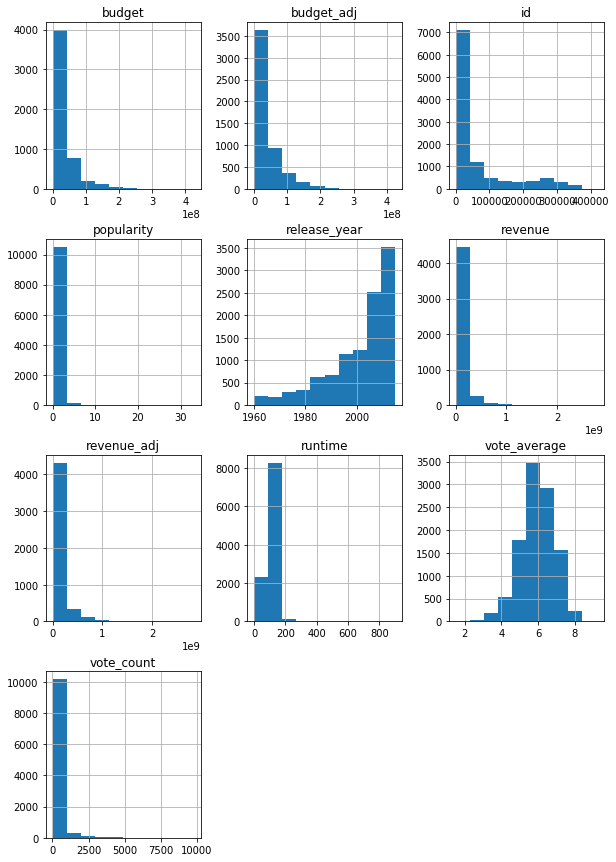

```python
df.hist(figsize=(10,15));
```

> Before addressing the research questions, we explored the distribution of the quantitative variables in our dataset to identify any trend in the data. The analysis showed that realease year data was skewed to the left, indicating that there has been an increasing trend in the movie release across years. Vote average data seemed to be approximately normally distributed. However, all the other quantitative variables in our dataset seemed to be skewed to the right.

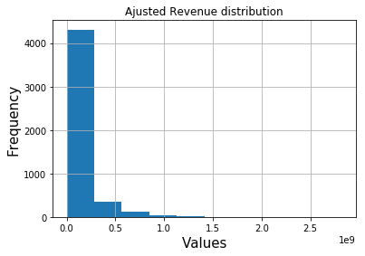

```python
df.revenue_adj.hist();
plt.title("Ajusted Revenue distribution")
plt.xlabel('Values',fontsize=15)
plt.ylabel('Frequency',fontsize=15)
plt.show();
```

> Before addressing the research questions, we were curious about the distribution of the the dependent variable (adjusted revenue) after. Thus, we plotted a histogram of adjusted revenue and results revealed that the adjusted revenue variable was skewed to the right

```python
#define a function to calculate the bin edges,provide labels for vote rating levels and create a new categorical column
# named vote_average_levels
def cut_by_num_summary (df_name, col_name):
    #find min, max, and quartiles
    min_val =df_name[col_name].describe()[3]
    lower_quartile=df_name[col_name].describe()[4]
    medium_val = df_name[col_name].describe()[5]
    upper_quartile = df_name[col_name].describe()[6]
    max_val = df_name[col_name].describe()[7]
    # Bin edges that will be used to "cut" the data into groups
    bin_edges = [min_val,lower_quartile,medium_val,upper_quartile, max_val]
    # Labels for the four average vote rating level groups
    bin_names = ['Low','Medium' ,'Moderately High' ,'High']
    #create the levels column
    name = '{}_levels'.format(col_name)
    df_name[name] = pd.cut(df_name[col_name], bin_edges, labels=bin_names,include_lowest = True)
    return df_name
```

> To avoid repetitive codes, we created a function cut_by_num_summary (), which takes two arguments (df_name,and col_name), divide the specified columns into four groups using the five number summary, adds the new column to our dataframe and then returns the new data frame with added columns

```python
# use the defined cut_by_num_summary function to divide vote average in two groups and create a column named vote_average_levels
df = cut_by_num_summary (df, 'vote_average')
df.head(1)
```

|  | id | imdb_id | popularity | budget | revenue | original_title | cast | director | overview | runtime | genres | production_companies | release_date | vote_count | vote_average | release_year | budget_adj | revenue_adj | vote_average_levels |
| --- | --- | --- | --- | --- | --- | --- | --- | --- | --- | --- | --- | --- | --- | --- | --- | --- | --- | --- | --- |
| 0 | 135397 | tt0369610 | 32.98576 | 150000000.00000 | 1513528810.00000 | Jurassic World | Chris Pratt\|Bryce Dallas Howard\|Irrfan Khan\|Vi... | Colin Trevorrow | Twenty-two years after the events of Jurassic ... | 124 | Action\|Adventure\|Science Fiction\|Thriller | Universal Studios\|Amblin Entertainment\|Legenda... | 2015-06-09 | 5562 | 6.50000 | 2015 | 137999939.28003 | 1392445892.52380 | Moderately High |

> We now call our defined function by inputing all our arguments and we get a new dataframe with a new categorical variable named vote_average_levels

```python
# Find the mean adjusted revenue of each vote average level with groupby
df.groupby('vote_average_levels').mean().revenue_adj
```

```
vote_average_levels
Low                50764216.57210
Medium             92426342.43266
Moderately High   121315538.84524
High              173849320.00598
Name: revenue_adj, dtype: float64
```

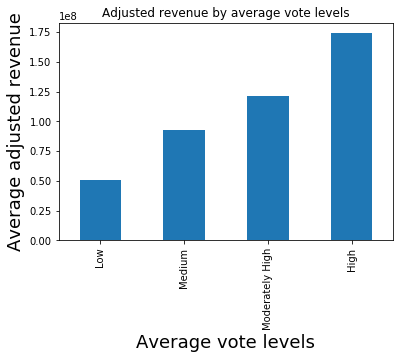

```python
#visualize the revenue by average rating levels
df.groupby('vote_average_levels')['revenue_adj'].mean().plot(kind="bar", title ="Adjusted revenue by average vote levels")
plt.xlabel('Average vote levels' , fontsize=18)
plt.ylabel('Average adjusted revenue' , fontsize=18)
plt.show();
```

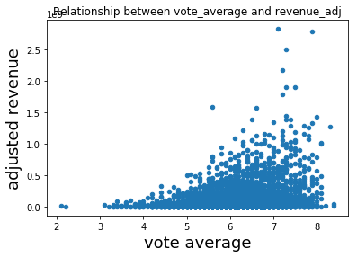

```python
# check for association between the variables
df.plot(x ="vote_average", y = "revenue_adj", kind ="scatter")
plt.title("Relationship between vote_average and revenue_adj")
plt.xlabel('vote average', fontsize=18)
plt.ylabel('adjusted revenue', fontsize =18)
plt.show();
```

### Do movies with high popularity yield higher adjusted revenue?

```python
# use the defined cut_by_num_summary function to divide vote average in two groups and create a column named vote_average_levels
df = cut_by_num_summary(df, 'popularity')
df.head(1)
```

|  | id | imdb_id | popularity | budget | revenue | original_title | cast | director | overview | runtime | genres | production_companies | release_date | vote_count | vote_average | release_year | budget_adj | revenue_adj | vote_average_levels | popularity_levels |
| --- | --- | --- | --- | --- | --- | --- | --- | --- | --- | --- | --- | --- | --- | --- | --- | --- | --- | --- | --- | --- |
| 0 | 135397 | tt0369610 | 32.98576 | 150000000.00000 | 1513528810.00000 | Jurassic World | Chris Pratt\|Bryce Dallas Howard\|Irrfan Khan\|Vi... | Colin Trevorrow | Twenty-two years after the events of Jurassic ... | 124 | Action\|Adventure\|Science Fiction\|Thriller | Universal Studios\|Amblin Entertainment\|Legenda... | 2015-06-09 | 5562 | 6.50000 | 2015 | 137999939.28003 | 1392445892.52380 | Moderately High | High |

> We now call our defined function by inputing all our arguments and we get a new dataframe with a new categorical variable named popularity_levels

```python
#find the average revenue for different popularity levels
df.groupby('popularity_levels').mean().revenue_adj
```

```
popularity_levels
Low                29103563.44467
Medium             32517182.32876
Moderately High    54112415.72474
High              194648937.03184
Name: revenue_adj, dtype: float64
```

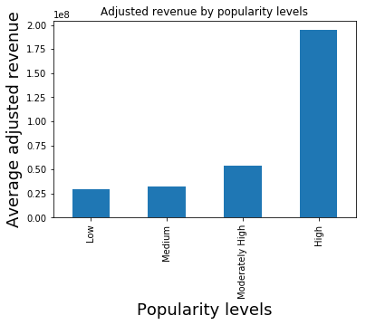

```python
#visualize the revenue by average rating levels
df.groupby('popularity_levels')['revenue_adj'].mean().plot(kind="bar", title ="Adjusted revenue by popularity levels")
plt.xlabel('Popularity levels' , fontsize=18)
plt.ylabel('Average adjusted revenue' , fontsize=18)
plt.show();
```

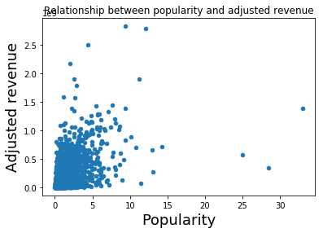

```python
#association between popularity and adjusted revenue
df.plot(x="popularity", y ="revenue_adj", kind="scatter");
plt.title("Relationship between popularity and adjusted revenue")
plt.xlabel('Popularity', fontsize=18)
plt.ylabel('Adjusted revenue', fontsize =18)
plt.show();
```

### Do higher runtime movies yield higher adjusted revenues?

```python
# use the defined cut_by_num_summary function to divide vote average in two groups and create a column named vote_average_levels
df = cut_by_num_summary(df, 'runtime')
df.head(1)
```

|  | id | imdb_id | popularity | budget | revenue | original_title | cast | director | overview | runtime | ... | production_companies | release_date | vote_count | vote_average | release_year | budget_adj | revenue_adj | vote_average_levels | popularity_levels | runtime_levels |
| --- | --- | --- | --- | --- | --- | --- | --- | --- | --- | --- | --- | --- | --- | --- | --- | --- | --- | --- | --- | --- | --- |
| 0 | 135397 | tt0369610 | 32.98576 | 150000000.00000 | 1513528810.00000 | Jurassic World | Chris Pratt\|Bryce Dallas Howard\|Irrfan Khan\|Vi... | Colin Trevorrow | Twenty-two years after the events of Jurassic ... | 124 | ... | Universal Studios\|Amblin Entertainment\|Legenda... | 2015-06-09 | 5562 | 6.50000 | 2015 | 137999939.28003 | 1392445892.52380 | Moderately High | High | High |

1 rows × 21 columns

> We now call our defined function by inputing all our arguments and we get a new dataframe with a new categorical variable named runtime_levels

```python
#group adjusted revenue by runtime levels and find the mean
df.groupby('runtime_levels').mean().revenue_adj
```

```
runtime_levels
Low                68436712.24839
Medium             78507260.23125
Moderately High    87295986.45100
High              186282095.27023
Name: revenue_adj, dtype: float64
```

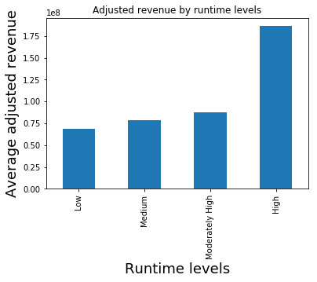

```python
#visualize the adjusted revenue by runtime
df.groupby('runtime_levels')['revenue_adj'].mean().plot(kind="bar", title ="Adjusted revenue by runtime levels")
plt.xlabel('Runtime levels' , fontsize=18)
plt.ylabel('Average adjusted revenue' , fontsize=18)
plt.show();
```

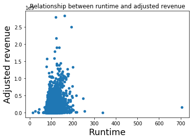

```python
#association between runtime and adjusted revenue
df.plot(x="runtime", y ="revenue_adj", kind="scatter", title="Relationship between runtime and adjusted revenue")
plt.xlabel('Runtime', fontsize=18)
plt.ylabel('Adjusted revenue', fontsize =18)
plt.show();
```

## Conclusions

> From the findings, it is clear that higher popular movies tend to yield higher adjusted revenue. In addition, movies with higher runtime tend to yield relatively higher revenue than those with lower runtime. Additionally, the findings revealed that movies with higher votes on average are more likely to yield more adjusted revenue as opposed to those with lower votes. These findings indicates that movies companies should focus on creating movies with higher runtime, increase the quality of the movies in order to increase the average movie rating and also, to focus on advertisement. Following these strategies can increase the overall revenues after adjusting for inflation. However, this study only focused on three independent variables among many other potential variables that influence the adjusted revenue. As such, further research should focus on other factors such as genres, year of release, and other variables as they can also influence the amount of revenue generated from movies. In addition, we replaced the zeros, in the revenue columns with NaN and there could be other possible strategies to impute the missing values in the revenue column.

```python
from subprocess import call
call(['python', '-m', 'nbconvert', 'Investigate_a_Dataset.ipynb'])
```

```
0
```